# Energy Data

DSA2101 Project

2024-04-12

# Introduction

Installing and loading the required packages for the project. We will be using the tidytuesdayR package to read in our data, tidyverse package to clean our data and ggthemes package to make our plots look better and improve the aesthetics of the plots in our project.

```r
#install.packages("tidytuesdayR")
#install.packages("tidyverse")
#install.packages("ggthemes")
library(tidytuesdayR)
library(tidyverse)
library(ggthemes)
```

Loading of the Energy data.

```r
owid_energy <- readr::read_csv('https://raw.githubusercontent.com/rfordatascience/tidytuesday/master/data/2023/2023-06-06/owid-energy.csv')

#Another method to load and read in the Energy data:
#tuesdata <- tidytuesdayR::tt_load('2023-06-06')
#owid_energy <- tuesdata$`owid-energy`
```

# Data Cleaning and Visualisation

For our project, our group would like to investigate the following question:

**What are the trends for global energy consumption from 1900 to 2021?**

In order to answer this question, we will be looking at/using the following variables in the data:

1. country: Geographic location
2. year: Year of observation
3. iso_code: ISO 3166-1 alpha-3 three-letter country codes
4. population: Population of country
5. gdp: Total real gross domestic product, inflation-adjusted
6. *energy type*_consumption: Primary energy consumption from the various *energy types*, measured in terawatt-hours

Using these variables in the data, we will proceed to clean the data and plot the following visualizations to answer our question:

1. Line Plot
2. Bar Chart
3. Proportional Stacked Area Chart

Before plotting the graphs, we will first perform some data exploration and inspection.

```r
time_period = owid_energy %>%
  filter(year < 1965 | year > 2021)

zero_data = rep(-1, 9)
zero_data[1] = sum(time_period$biofuel_consumption, na.rm = TRUE)
zero_data[2] = sum(time_period$coal_consumption, na.rm = TRUE)
zero_data[3] = sum(time_period$gas_consumption, na.rm = TRUE)
zero_data[4] = sum(time_period$hydro_consumption, na.rm = TRUE)
zero_data[5] = sum(time_period$nuclear_consumption, na.rm = TRUE)
zero_data[6] = sum(time_period$oil_consumption, na.rm = TRUE)
zero_data[7] = sum(time_period$other_renewable_consumption, na.rm = TRUE)
zero_data[8] = sum(time_period$solar_consumption, na.rm = TRUE)
zero_data[9] = sum(time_period$wind_consumption, na.rm = TRUE)

zero_data
```

```
## [1] 0 0 0 0 0 0 0 0 0
```

Preliminary inspection of the data reveals that there is only data for consumption of energy starting from 1965. However, there is data for energy production using coal, oil and gas starting from 1900. This could be due to the lack of advanced technologies and systems to collect information on energy consumption and their sources. The above findings are critical as we are looking into the trends in energy consumption through the years.

```r
head(unique(owid_energy$country), 10)
```

```
##  [1] "Afghanistan"    "Africa"         "Africa (BP)"    "Africa (Ember)"
##  [5] "Africa (Shift)" "Albania"        "Algeria"        "American Samoa"
##  [9] "Angola"         "Antarctica"
```

```r
owid_energy = owid_energy %>%
  filter(!str_detect(country, "(BP)")) %>%
  filter(!str_detect(country, "(Ember)")) %>%
  filter(!str_detect(country, "(Shift)")) %>%
  filter(!str_detect(country, "(EIA)"))

head(unique(owid_energy$country), 10)
```

```
##  [1] "Afghanistan"         "Africa"              "Albania"
##  [4] "Algeria"             "American Samoa"      "Angola"
##  [7] "Antarctica"          "Antigua and Barbuda" "Argentina"
## [10] "Armenia"
```

The above data inspection also reveals that there are duplicated entries for each year and country. The variation in labels are due to the various sources of data from different organisations. In this report, we will be using the boundaries for each country as defined by “Our World in Data”. They made the necessary calculations and adjustments for the data set to reflect the energy data based on their definition of boundaries.

Since we are interested in global trends, we have to first filter the data for individual countries, which are coded for by valid *iso_code* values.

```r
#filtering to retain only data for individual countries
owid_energy = owid_energy %>%
  filter(!is.na(iso_code))

head(unique(owid_energy$country), 10)
```

```
##  [1] "Afghanistan"         "Albania"             "Algeria"
##  [4] "American Samoa"      "Angola"              "Antarctica"
##  [7] "Antigua and Barbuda" "Argentina"           "Armenia"
## [10] "Aruba"
```

The data is now cleaned and ready for use.

## Visualisation 1 - Line Chart

For our first visualisation, we will be looking at the global trends for energy consumption. We are using a line plot as this is the simplest and clear visualisation to identify trends over time.

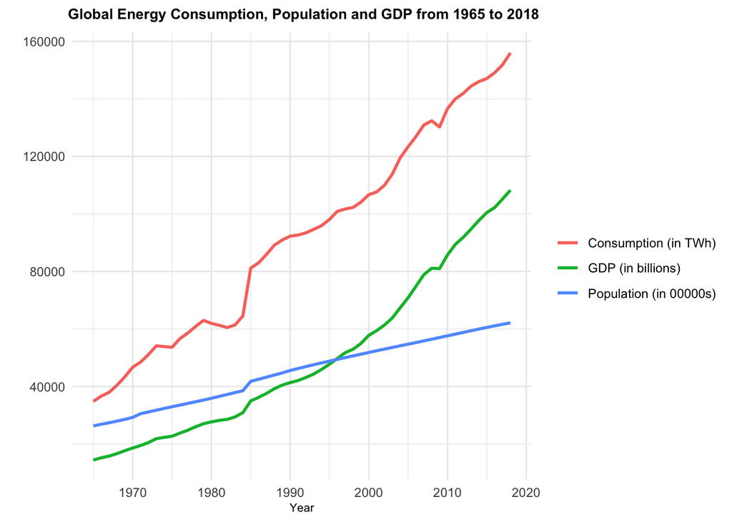

```r
dataset_1 <- owid_energy %>%

  # We will select the relevant columns. In order to collect all the energy data, we will only need fossil_fuel_consumption (coal, oil and gas), renewables_consumption (biofuel, hydro, solar, wind, other renewables) & nuclear energy. As using the energy types that are already included in the broader categories will unnecessarily extrapolate the data for the consumption and population, we have decided to not include these columns in our vizualisations.
  select(country, year, population, gdp, fossil_fuel_consumption, renewables_consumption, nuclear_consumption) %>%

 # The consumption data starts from 1965 and roughly ends in 2021
  filter(year >= 1965, year <= 2021) %>%

  # We replace all the NA values with 0. The NA values indicate that the type of energy was just not consumed in that year.
  replace(is.na(.), 0) %>%

  # We created a column called "total_consumption" to sum up the previous energy columns for each entry.
  mutate(total_consumption = fossil_fuel_consumption + renewables_consumption + nuclear_consumption) %>%

  # We will filter out the unnecessary data. For this, we will filter out data entries where there is total_consumption of > 0 (meaning that the country has data on its energy consumption), population > 0 (meaning that the country also has data on its population) and gdp > 0 (meaning the country has data on its gdp). For example, if a country has 0 population but has an energy consumption, we will not use that data entry as it may skew our calculations later on.
  filter(total_consumption > 0 & population > 0 & gdp > 0)


# Now, to prepare the data for the visualisation, we will:
# 1.We will group the data by year using the group_by() function, which will allow the future summarise() function to be used to sum up the different values according to the year.
# 2.Now, we will use the summarise() function to get the total population and total consumption in each year.
# 3.With the summarised values, we will use pivot_longer()/gather() to contain the category(Population & Consumption) in one column, and their respective values in another
dataset_1 <- dataset_1 %>%

  # Group by the year(the subsequente summarize() function will be applied on the different years)
  group_by(year) %>%

  # Choose the relevant columns from the data.
  select(year, population, gdp, total_consumption) %>%

  # Use summarise to get the total population and total consumption of energy for each year. We will divide the total_pop by 3 as the population will be triple counted for each year due to 3 types of energy consumptions.
  summarise(total_population = sum(population), total_consumption = sum(total_consumption), total_gdp = sum(gdp)) %>%

  # Conversion of the population to be in terms of 00,000s.
  mutate(total_population = total_population / 10**5) %>%

  # Conversion of the global GDP to be in terms of 000,000,000s (billions)
  mutate(total_gdp = total_gdp / 10**9) %>%

  # We perform a gather/pivot_longer function to prepare the columns for our plot.
  gather(c(total_population, total_consumption, total_gdp), key = "type", value = "value")


# We will set the scipen to 99 to remove the scientific notation in the graph for the y-axis.
options(scipen = 99)

# We will set the x axis to be year, y axis to be the value, and color to be the categories.
plot_1 <- ggplot(data = dataset_1, aes(x = year, y = value, color = type)) +

  # We use geom_line() to create a line graph.
  geom_line(lwd = 1) +

  # We change the theme to theme_minimal() to easily vizualise the trend.
  theme_minimal() +

  # We adjust the title, x-axis and y-axis labels of the plot accordingly
  labs(title = bquote(~bold("Global Energy Consumption, Population and GDP from 1965 to 2018")), x = "Year", y = "") +

  # We rename the legend accordingly
  scale_color_discrete(name = "", labels = c("Consumption (in TWh)", "GDP (in billions)", "Population (in 00000s)")) +

  # We change the size of the title and the y-axis label
  theme(plot.title = element_text(size = 10, hjust = 0.5), axis.title.y = element_text(size = 8), axis.title.x = element_text(size = 8))

plot_1
```

## Visualisation 2 - Bar Chart (with facet wrap)

[figure not shown]

```r
dataset_2 = owid_energy %>%

  # The consumption data starts from 1965 roughly ends in 2021
  filter(year >= 1965, year <= 2021) %>%

  # We will choose the year and all columns that end with the word consumption. Additionally, while we include all columns that end with the word consumption, we exclude:
  # 1.Fossil Fuels, as it is the sum of energy consumption from Coal, Gas and Oil
  # 2.Renewables, as it is the sum of Hydro, Other Renewables (including Biofuel), Solar and Wind
  # 3.Low Carbon, as it consists of Renewables and Nuclear
  # 4.Primary Energy, as it does not help in our analysis of the various sources of energy
  select(year, ends_with("consumption"), -c("fossil_fuel_consumption","renewables_consumption", "low_carbon_consumption", "primary_energy_consumption")) %>%

  # We change the year to date format for formatting purposes.
  mutate(year = ym(paste0(as.character(year),"-01"))) %>%

  # We renamed the year column to date instead
  rename(date = year) %>%

  # We will group the data by the date so that we can calculate the sum of consumption for each of the energy types. We will update the respective energy consumption columns accordingly.
  group_by(date) %>%

  # We will set na.rm = TRUE, since there may be NA values in the data that we did not replace.
  mutate(biofuel_consumption = sum(biofuel_consumption, na.rm = TRUE)) %>%
  mutate(coal_consumption = sum(coal_consumption, na.rm = TRUE)) %>%
  mutate(gas_consumption = sum(gas_consumption, na.rm = TRUE)) %>%
  mutate(hydro_consumption = sum(hydro_consumption, na.rm = TRUE)) %>%
  mutate(nuclear_consumption = sum(nuclear_consumption, na.rm = TRUE)) %>%
  mutate(oil_consumption = sum(oil_consumption, na.rm = TRUE)) %>%
  mutate(other_renewable_consumption = sum(other_renewable_consumption, na.rm = TRUE)) %>%
  mutate(solar_consumption = sum(solar_consumption, na.rm = TRUE)) %>%
  mutate(wind_consumption = sum(wind_consumption, na.rm = TRUE)) %>%
  # We apply distinct to remove any duplicates as we only want to keep the rows that are #unique.
  distinct() %>%

  # We will ungroup the previous group_by so that the groupings do not follow subsequently.
  ungroup(date)


# To prepare the data for the plot, we will perform a pivot_longer to combine the various energy types into a column named "energy_type", with the values stored in the new column "consumption".
dataset_2 <- dataset_2 %>%

  # We will input the columns from biofuel_consumption (the start) to wind_consumption (the end).
  pivot_longer(c("biofuel_consumption":"wind_consumption"), names_to = "energy_type", values_to = "consumption") %>%

  # We will remove the "_consumption" at the end of each energy type
  mutate(energy_type = str_remove(energy_type, "_consumption")) %>%

  # We will replace any remaining underscores with a blank space. This is primarily for our "other_renewable" column
  mutate(energy_type = str_replace_all(energy_type, "_", " ")) %>%

  # We will uppercase the words where necessary, like proper() but in R.
  mutate(energy_type = str_to_title(energy_type)) %>%

  # We add a 's' to the end of "Other Renewable" energy_type by performing a string operation.
  mutate(energy_type = str_replace_all(energy_type, "Renewable", "Renewables")) %>%

  # We re-order the plots in such a way that they are in ascending order of their max value throughout the years.
  mutate(energy_type = reorder(energy_type, consumption, max))


# We will set the scipen to 99 to remove the scientific notation in the graph in the y-axis.
options(scipen = 99)

# We will plot the graph accordingly, by firstly setting the global data and aesthetics of the plot.
plot_2 <- ggplot(dataset_2, aes(x = year(date), y = consumption)) +

  # We will use geom_col, since we are using the values in the data rather than count of the data (geom_bar)
  geom_col(linewidth = 0, fill = "steelblue", colour = "steelblue") +

  # Create the labels of the plot.
  labs(title = bquote(~bold("Bar Charts for Energy Consumption from each source from 1900 to 2021")), x = "Year", y = "Energy Consumption (in TWh)") +

  # Facet wrap on the type of energy source.
  facet_wrap(~energy_type) +

  # We will go with the minimal theme to observe the trend easily.
  theme_minimal() +

  theme(plot.title = element_text(size = 10, hjust = 0.5))

plot_2
```

From the above visualisation, we can observe a general increase in consumption of energy from all the sources. For some forms of renewable energy sources(biofuel, solar and wind), their consumption only started in towards the end of the 20th century.

## Visualisation 3 - Proportional Stacked Area Chart

For the third visualisation, we would like to investigate the trends in consumption of lower carbon energy and energy generated from fossil fuels. They are defined as follows:

1. Low carbon energy sources: Biofuel, Hydro, Nuclear, Solar, Wind & Other Renewables
2. Fossil Fuels: Coal, Gas & Oil

A Proportional Stacked Area chart is used to compare the proportion of energy supplied by each category of energy sources. Using this enables us to establish a baseline that is independent of the year-on-year changes in global energy consumption.

[figure not shown]

```r
dataset_3 = owid_energy %>%

  # The consumption data starts from 1965 and roughly ends in 2021.
  filter(year >= 1965, year <= 2021) %>%

  # Given how we want to investigate the "Clean" and "Non-clean" energy sources, we will use the data provided in the form of "fossil_fueL_consumption" and "low_carbon_consumption".
  select(year, fossil_fuel_consumption, low_carbon_consumption) %>%

  # We change the year to date format for formatting purposes.
  mutate(year = ym(paste0(as.character(year),"-01"))) %>%

  # Rename the year column to date instead.
  rename(date = year) %>%

  # We will group the data by the date so that we can calculate the sum of consumption for both clean and non-clean energy. We will then update the respective energy consumption columns.
  group_by(date) %>%

  # Once again, we set na.rm = TRUE as there may be NA values in the data that we did not replace.
  mutate(fossil_fuel_consumption = sum(fossil_fuel_consumption, na.rm = TRUE)) %>%
  mutate(low_carbon_consumption = sum(low_carbon_consumption, na.rm = TRUE)) %>%

  # We will ungroup the data as good practice so that the groupings will not be carried forward as well for our future analysis.
  ungroup(date) %>%

  # We add distinct to filter for any redundant values by removing all the duplicate rows.
  distinct()


# To prepare the data for this plot, we will once again perform pivot longer on the data to split them into their respective categories.
dataset_3 <- dataset_3 %>%

  # In this case, we only have 2 categories: fossil fuel and low carbon. We will categorize them as per last data set.
  pivot_longer(c("fossil_fuel_consumption":"low_carbon_consumption"), names_to = "energy_type", values_to = "consumption") %>%

  # Once again, we will perform similar string operations to last dataset. Firstly, we will remove the "_consumption" at the end of the categories.
  mutate(energy_type = str_remove(energy_type, "_consumption")) %>%

  # Secondly, We will replace any remaining underscores with a blank space, which is for both categories.
  mutate(energy_type = str_replace_all(energy_type, "_", " ")) %>%

  # Lastly, We will uppercase the words.
  mutate(energy_type = str_to_title(energy_type)) %>%

  # We will group by the date so that we can perform aggregate functions on the consumption value.
  group_by(date) %>%

  # In this case, we want to calculate the total consumption for each year using sum().
  mutate(sum_consum = sum(consumption)) %>%

  # We will then use this total to find the percentage of consumption for both clean and non-clean energy sources.
  mutate(percentage = consumption / sum_consum * 100)


# We will now plot the graph, and specify the data and global aesthetics as required.
plot_3 <- ggplot(dataset_3, aes(x = date, y = percentage, fill = energy_type)) +

  #We will use geom_area() to create the Proportional Stacked Area chart.
  geom_area(alpha = 0.6 , linewidth = 1) +

  # Labels for the plot.
  labs(title = bquote(~bold("Proportion of Low Carbon and Fossil Fuel Energy Consumption from 1900 to 2021")) , x = "Year", y = "Percentage of Total Energy Consumption (in %)", fill = "Category of energy source") +

  # We shall use the minimal theme to observe the data easily and to standardize it with our previous plots.
  theme_minimal() +

  theme(plot.title = element_text(size = 10, hjust = 0.4))

plot_3
```

From the visualisation, we can observe that the proportion of energy consumption from low carbon sources is increasing while that from fossil fuel is decreasing.

# Discussion

# Conclusion

From the data, we can conclude that global trends in energy consumption are not only increasing, but also moving towards cleaner energy sources. This is also aligned with the global direction for energy sources.

# References:

1. Energy Data (https://github.com/rfordatascience/tidytuesday/blob/master/data/2023/2023-06-06/readme.md)
2. Worldometer (https://www.worldometers.info/world-population/world-population-by-year/)
3. MPRA (https://mpra.ub.uni-muenchen.de/110972/)
4. The Lowy Institute (https://www.lowyinstitute.org/the-interpreter/world-energy-outlook-good-bad-ugly)
5. IEA 1 (https://www.iea.org/news/the-world-s-coal-consumption-is-set-to-reach-a-new-high-in-2022-as-the-energy-crisis-shakes-markets)
6. IEA 2 (https://www.iea.org/news/renewable-power-s-growth-is-being-turbocharged-as-countries-seek-to-strengthen-energy-security)

# About

This project was developed for DSA2101 Essential Data Analytics Tools: Data Visualization at the National University of Singapore (NUS). The team is comprised of the following members:

```
##                  Student 1
## Name             "Ng Junlin Benjamin"
## Year             "2"
## Major            "Data Science and Analytics"
## Responsibilities "Provided detailed explanations for the plots. Verified the accuracy of our plots by cross-checking with relevant data sources."
##                  Student 2
## Name             "Yu Zifan"
## Year             "2"
## Major            "Data Science and Analytics"
## Responsibilities "Innovated and suggested ideas during the group meetings."
##                  Student 3
## Name             "Koh Ni Shyuen"
## Year             "2"
## Major            "Data Science and Analytics"
## Responsibilities "Defined the key terms & variables that were used in the project."
##                  Student 4
## Name             "Owen Tan Keng Leng"
## Year             "2"
## Major            "Data Science and Analytics"
## Responsibilities "Designed and coded the plots for the project, defining the key plots to be included in the project."
##                  Student 5
## Name             "Jerilyn Chan Ying Ting"
## Year             "2"
## Major            "Data Science and Analytics"
## Responsibilities "Performed deep research about the history of the data, giving relevant context to understand the data and question better. Helped to design and code the plots."
```